# Elevation and Level of Extinction

Level of extinction sorted by severity.

| Degree.of.Extinction | Descriptions |
| --- | --- |
| Vulnerable | most children speak the language, but it may be restricted to certain domains, e.g., home |
| Definitely endangered | children no longer learn the language as a 'mother tongue' in the home |
| Severely endangered | language is spoken by grandparents and older generations; while the parent generation may understand it, they do not speak it to children or among themselves |
| Critically endangered | the youngest speakers are grandparents and older, and they speak the language partially and infrequently |
| Extinct | there are no speakers left |

Elevation data collected from Google Map based on latitude and longitude using following function:

```r
getElevation<-function(ext.df){
  require(jsonlite)
  #Splitting the dataframe so that we can query more lat.ln per query, set to 5
  c<-as.integer(nrow(ext.df)/5 +1)
  ext.df$group<-rep(1:c, times=1, length.out=nrow(ext.df), each=5)
  group.lst<-split(ext.df, ext.df$group)

  latln.df<-lapply(group.lst, function(row) {
    coord <- paste(row$Latitude, row$Longitude, sep = ",")
    url_string<-URLencode(paste("https://maps.googleapis.com/maps/api/elevation/json?locations=",
                                paste(coord, collapse="|"), sep = ""))
    connect <- url(url_string); on.exit(close(connect), add = TRUE)
    rgc <- fromJSON(paste(readLines(connect), collapse = ''))
    if(rgc$status != 'OK'){
      warning(paste('get eleveation failed - bad location? ID = "',
                    paste(row$ID, collapse = ","), '"', sep = ''))
    }
    data.frame(ID=row$ID, coord=coord, elevation=rgc$results$elevation, resolution=rgc$results$resolution)
  })
  latln.df

}
ext.lang<-read.csv("../input/data.csv", stringsAsFactors = F)
which(is.na(ext.lang$Latitude)==TRUE)
latln.df<-getElevation(ext.lang[-c(743,2201,2336),])
lat.ln.df<-bind_rows(latln.df)
write.csv(lat.ln.df, file = "./collected_data/lat.lng.elevation.csv")
ext.lang.elevation<-merge(ext.lang, lat.ln.df, by="ID", all=T)
```

Three rows do not have lat-long data, which is

```r
missing.latln<-which(is.na(ext.lang$Latitude)==TRUE)
kable(ext.lang[missing.latln, names(ext.lang.elevation) %in%
                           c("ID", "Countries", "Name.in.English", "Degree.of.endangerment")])
```

|  | ID | Name.in.English | Countries | Degree.of.endangerment |
| --- | --- | --- | --- | --- |
| 743 | 2057 | Romani (Colombia) | Colombia | Vulnerable |
| 2201 | 2154 | Umbrul | Vanuatu | Critically endangered |
| 2336 | 1904 | Dorasque | Panama | Extinct |

Showing histogram by level of extinction with bin from elevation for every 500 meters

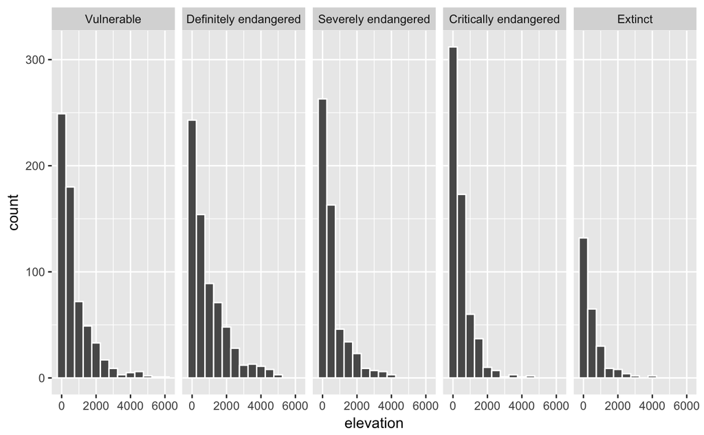

```r
require(ggplot2)
## Refactor according to severity
ext.lang.elevation$Degree.of.endangerment<-factor(ext.lang.elevation$Degree.of.endangerment,
                                levels=c("Vulnerable", "Definitely endangered",
                                         "Severely endangered", "Critically endangered", "Extinct"))
ele<-ggplot(ext.lang.elevation, aes(x=elevation)) + geom_histogram(binwidth = 500, colour="white")
ele + facet_grid(. ~ Degree.of.endangerment)
```

#### Showing extinction level with regards to elevation

First we categorized the elevation to “low”, “mid”, “high land” and “high mountain” based on elevation level of <300m, 300m-1000m, 1000m-2000m and >2000m.

```r
categorizeElevation<-function(){
  ele.cat<-mapply(function(alt_range, grp_name) {
    row<-which(ext.lang.elevation$elevation >= alt_range[1] & ext.lang.elevation$elevation < alt_range[2])
    data.frame(ID=ext.lang.elevation[row, "ID"], ele.group=rep(grp_name, length(row)))

  }, list(c(-9999,300), c(300,1000), c(1000,2000), c(2000, 99999)), c("<300m", "300m-1000m", "1000m-2000m", ">2000m"))
  ele.cat.df<-data.frame(ID=unlist(ele.cat[1,]), ele.group=unlist(ele.cat[2,]))
  ele.cat.df
}
ext.lang.elevation<-merge(ext.lang.elevation, categorizeElevation(), by="ID", all=T)
```

We then plot the percentage of each extinction levels on 4 pie chart to representing the 4 elevation categries

```r
data<-tapply(ext.lang.elevation$ele.group, list(ext.lang.elevation$ele.group,
                                                ext.lang.elevation$Degree.of.endangerment), length)
r<-row.names(data)
data.ele<-mutate(as.data.frame(data, row.names = row.names(data)), Total=rowSums(data))
row.names(data.ele)<-r
kable(data.ele)
```

|  | Vulnerable | Definitely endangered | Severely endangered | Critically endangered | Extinct | Total |
| --- | --- | --- | --- | --- | --- | --- |
| <300m | 285 | 265 | 284 | 338 | 149 | 1321 |
| 300m-1000m | 185 | 182 | 171 | 188 | 62 | 788 |
| 1000m-2000m | 100 | 134 | 62 | 64 | 29 | 389 |
| >2000m | 57 | 99 | 37 | 16 | 12 | 221 |

```r
require(plotly)
colortone<-list(
  colors = c(rgb(43,131,186, maxColorValue=255), rgb(171,221,164, maxColorValue=255),
             rgb(255,255,191, maxColorValue=255), rgb(253,174,97, maxColorValue=255),
             rgb(215,25,28, maxColorValue=255)))
subTitleStyle<-list(
  font = list(family = "Courier New, monospace", size = 18, color = "black"),
  xref = "paper",
  yref = "paper",
  yanchor = "bottom",
  xanchor = "center",
  align = "left",
  showarrow = FALSE)
plot_ly() %>%
  add_pie(data = data.frame(n=data[1,], doe=names(data[1,])), labels = ~doe, values = ~n,
          textposition="outside", direction="clockwise", sort=F, rotation=0,
          marker=colortone,
          name = "<300m", domain = list(x = c(0, 0.4), y = c(0.6, 1))) %>%
  layout(annotations=append(list(text="<300m", x=0, y=0.5), subTitleStyle)) %>%
  add_pie(data = data.frame(n=data[2,], doe=names(data[2,])), labels = ~doe, values = ~n,
          textposition="outside", direction="clockwise", sort=F, rotation=0,
          name = "300m-1000m", domain = list(x = c(0.6, 1), y = c(0.6, 1))) %>%
  layout(annotations=append(list(text="300m-1000m", x=1, y=0.5), subTitleStyle)) %>%
  add_pie(data = data.frame(n=data[3,], doe=names(data[3,])), labels = ~doe, values = ~n,
          textposition="outside", direction="clockwise", sort=F, rotation=180,
          name = "1000m-2000m", domain = list(x = c(0, 0.4), y = c(0.4, 0))) %>%
  layout(annotations=append(list(text="1000m-2000m", x=0, y=-0.1), subTitleStyle)) %>%
  add_pie(data = data.frame(n=data[4,], doe=names(data[4,])), labels = ~doe, values = ~n,
          textposition="outside", direction="clockwise", sort=F, rotation=180,
          name = ">2000m", domain = list(x = c(0.6, 1), y = c(0.4, 0))) %>%
  layout(annotations=append(list(text=">2000m", x=1, y=-0.1), subTitleStyle)) %>%
  layout(title = 'Levels of extinction on elevation', showlegend = T,
                xaxis = list(showgrid = FALSE, zeroline = FALSE, showticklabels = F),
                yaxis = list(showgrid = FALSE, zeroline = FALSE, showticklabels = F))
```

[interactive chart not shown]

#### Observation

Higher elevation that is more than 2000 meters seem to show higher language retention, where most extinct languages are majority below 2000 meters. For category **Vulnerable**, **Definately endangered** and **Severely endangered**, there are more languages that is spoken in higher altitute with more than 2000 meters.

This prelimary observation based on language count by elevation seem to show some sign of language retention based on elevation with a critical point at 2000 meters, but is not the only factor that is threatening the language.

Looking into the distribution of each extinction level on 4 elevation category, the ratio for **Extinct** is decreasing and **Definately endangered** is alarming showing sharp increase especially on elevation > 2000m above sea level. This may show that younger population may start to migrate to lower land area for better economics and assimilate to main pupulation having less younger generation to continue on the language.